# Observations of Red Wine Quality by Subham Biswas

# Multivariate Plots Section

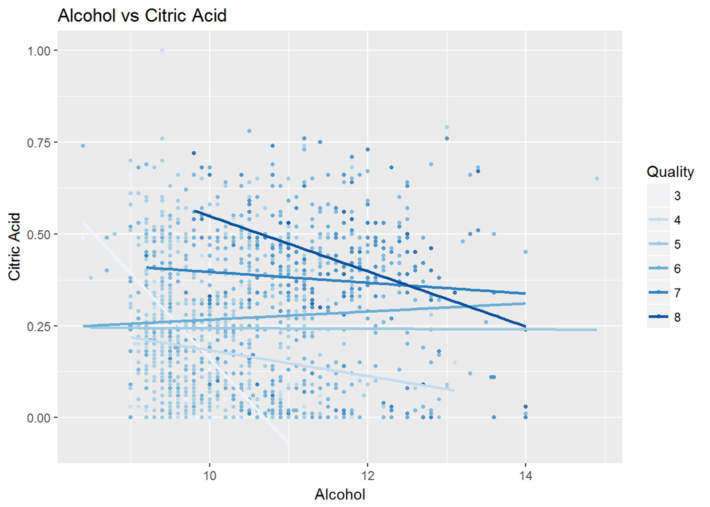

```r
ggplot(aes(x = alcohol,
           y = citric.acid  , color = factor(quality)),
       data = red_wine) +
      geom_point(alpha = 0.8, size = 1) +
      geom_smooth(method = "lm", se = FALSE,size=1)  +
  scale_color_brewer(type='seq',
                   guide=guide_legend(title='Quality'))+
  ggtitle("Alcohol vs Citric Acid") +
  xlab("Alcohol") +
  ylab("Citric Acid")
```

From this plot we can say that redwine with good rating is more clustered from 11 to 13/dm^3 alcohol and 0.25 to 0.75gm/dm^3 Citric acid

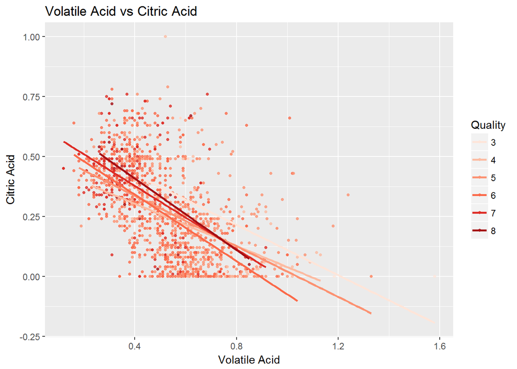

```r
ggplot(aes(x = volatile.acidity,
           y = citric.acid  , color = factor(quality)),
       data = red_wine) +
      geom_point(alpha = 0.8, size = 1) +
      geom_smooth(method = "lm", se = FALSE,size=1)  +
  scale_color_brewer(type='seq',
                   guide=guide_legend(title='Quality'), palette = "Reds")+
  ggtitle("Volatile Acid vs Citric Acid") +
  xlab("Volatile Acid") +
  ylab("Citric Acid")
```

We find out something interesting that most of the good wines are clustered around 0.2 to 0.6 gm/dm^3 Volatile acid and 0.25 to 0.75 gm/dm^3 Citric Acid

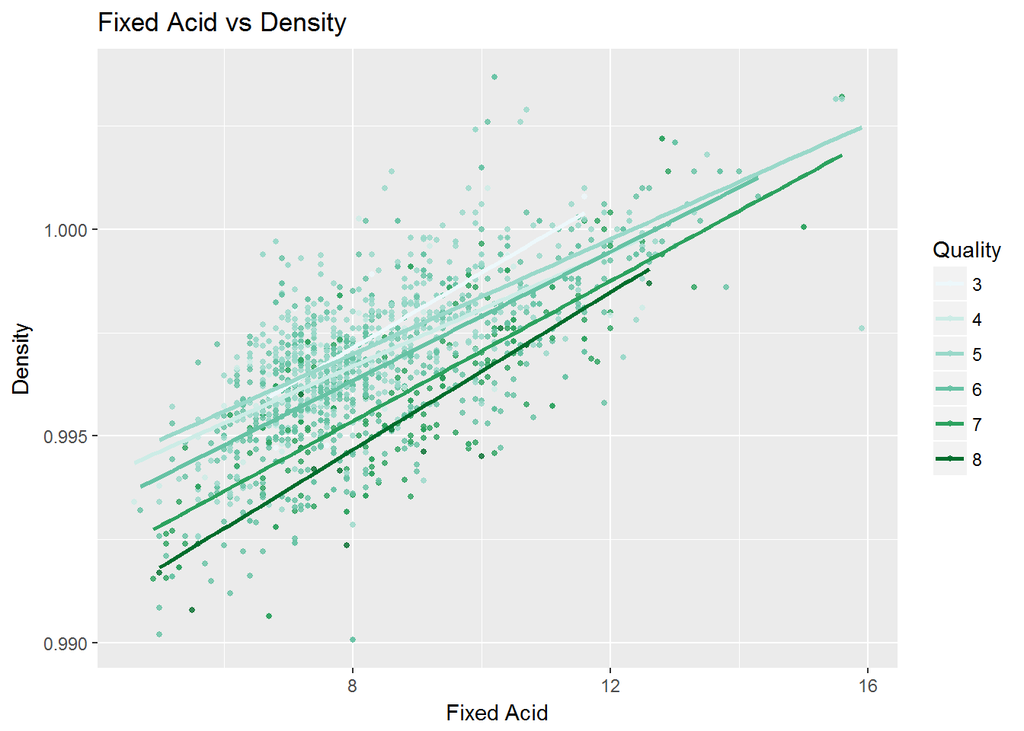

```r
ggplot(aes(x = fixed.acidity,
           y = density  , color = factor(quality)),
       data = red_wine) +
      geom_point(alpha = 0.8, size = 1) +
      geom_smooth(method = "lm", se = FALSE,size=1)  +
  scale_color_brewer(type='seq',
                   guide=guide_legend(title='Quality'), palette = 2)+
  ggtitle("Fixed Acid vs Density") +
  xlab("Fixed Acid") +
  ylab("Density")
```

Good wines seems to be distributed across the plot.

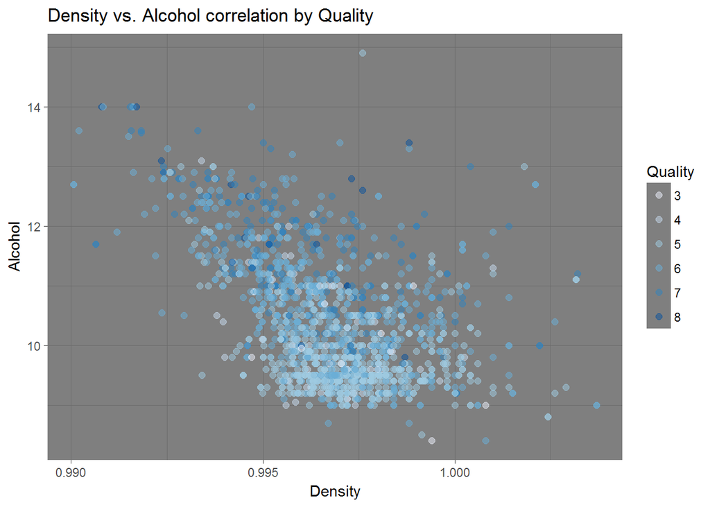

```r
ggplot(red_wine, aes(x = density, y = alcohol, color = as.factor(quality))) +
  geom_point(alpha = 1/2, size = 2) +
  scale_color_brewer() +
  ggtitle('Density vs. Alcohol correlation by Quality') +
  ylab("Alcohol") +
  xlab("Density") +
  labs(color = "Quality")+theme_dark()
```

We can see that there is large conectration of average rating wines in range from 0.995 to 1 gm/cm^3 density and 9 to 10 (%volume) alchol. Whereas good rating wines have high concentraion of Alcohol

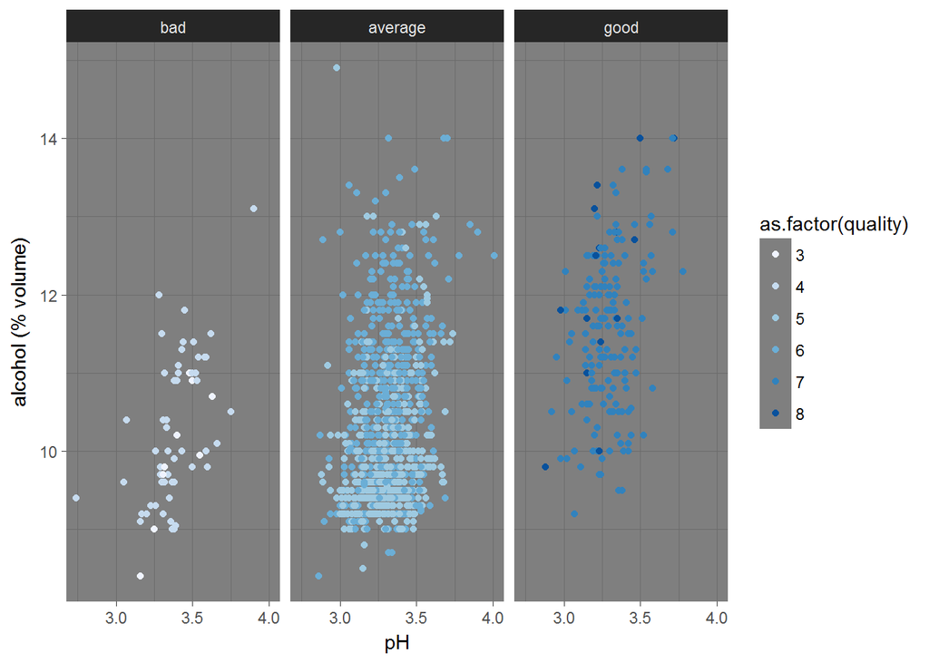

```r
ggplot(data = red_wine, aes(pH, alcohol, color = as.factor(quality))) +
  geom_point() +
  facet_wrap(~rating) +
  ylab('alcohol (% volume)') +
  theme_dark() +
  scale_color_brewer(type = 'seq', palette = 1)
```

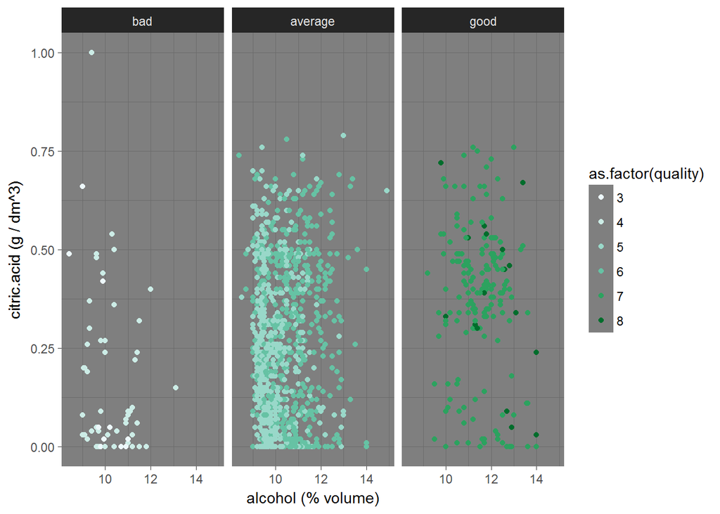

```r
ggplot(data = red_wine, aes(alcohol, citric.acid, color = as.factor(quality))) +
  geom_point() +
  facet_wrap(~rating) +
  xlab('alcohol (% volume)') +
  ylab('citric.acid (g / dm^3)') +
  scale_color_brewer(type = 'seq', palette = 2) +
  theme_dark()
```

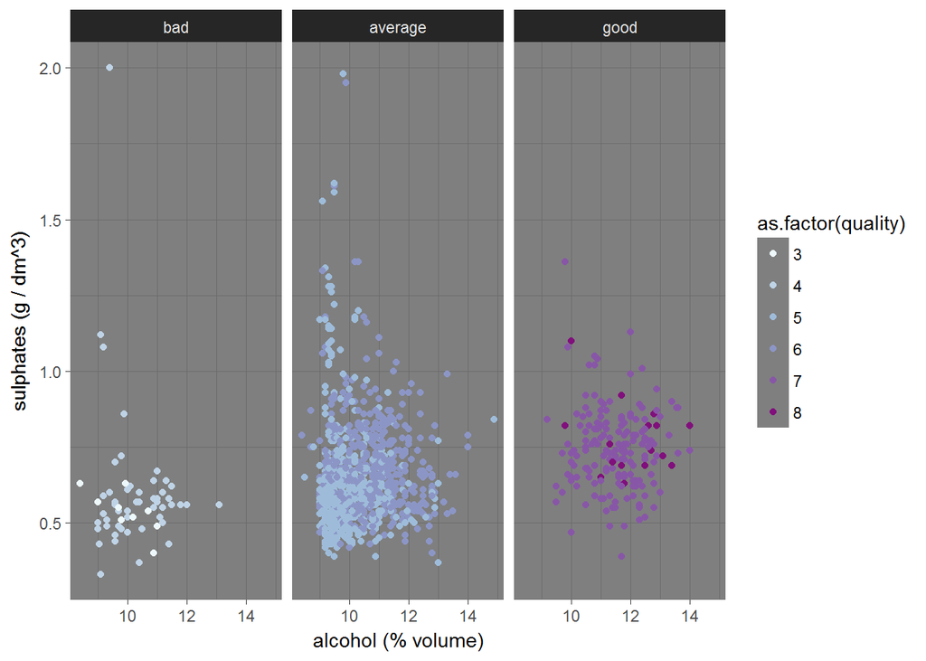

```r
ggplot(data = red_wine, aes(alcohol, sulphates, color = as.factor(quality))) +
  geom_point() +
  facet_wrap(~rating) +
  xlab('alcohol (% volume)') +
  ylab('sulphates (g / dm^3)') +
  scale_color_brewer(type = 'seq', palette = 3) +
  theme_dark()
```

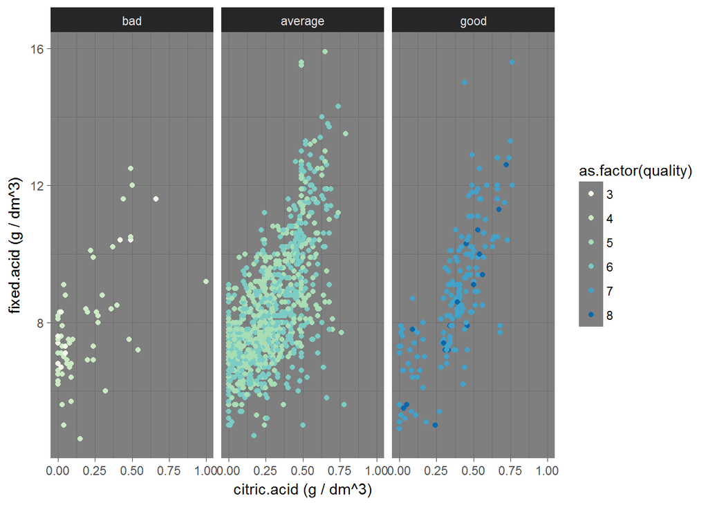

```r
ggplot(data = red_wine, aes(citric.acid, fixed.acidity, color = as.factor(quality))) +
  geom_point() +
  facet_wrap(~rating) +
  xlab('citric.acid (g / dm^3)') +
  ylab('fixed.acid (g / dm^3)')  +
  scale_color_brewer(type = 'seq', palette = 4) +
  theme_dark()
```

# Multivariate Analysis

### Were there any interesting or surprising interactions between features?

Good rating wine have low concentration of Volatile acid and high concentration of Citric acid

### OPTIONAL: Did you create any models with your dataset? Discuss the strengths and limitations of your model.

Let us use decision tree as our model

```r
set.seed(42)
wine_sample <- sample_n(2, tbl = red_wine, size = 150)
t <- sample(2, nrow(wine_sample),replace = TRUE, prob =c(0.7, 0.3))
train <- wine_sample[t ==1,]
test <- wine_sample[t ==2,]
my_formula <- rating ~ volatile.acidity+density+alcohol+pH+quality
wine_ctree <- ctree(my_formula, data = train)
table(predict(wine_ctree),train$rating)
```

```
##
##           bad average good
##   bad       7       0    0
##   average   0      88    0
##   good      0       0   15
```

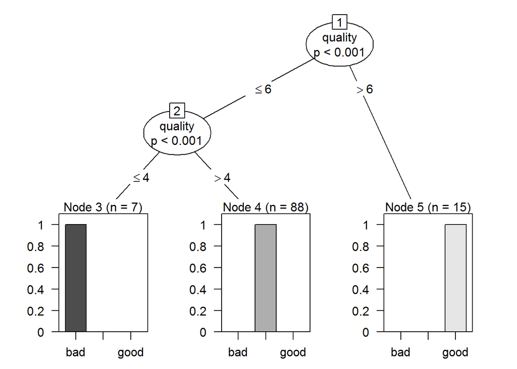

```r
plot(wine_ctree)
```

```r
testpred <- predict(wine_ctree, newdata = test)
table(testpred, test$quality)
```

```
##
## testpred   4  5  6  7
##   bad      1  0  0  0
##   average  0 21 13  0
##   good     0  0  0  5
```

No error in predicted values of test data , i think this is the strength of my model.Also by increasing the number of variables i can increase the efficiency of my model.

# Final Plots and Summary

### Plot One : Effect of alcohol on wine quality

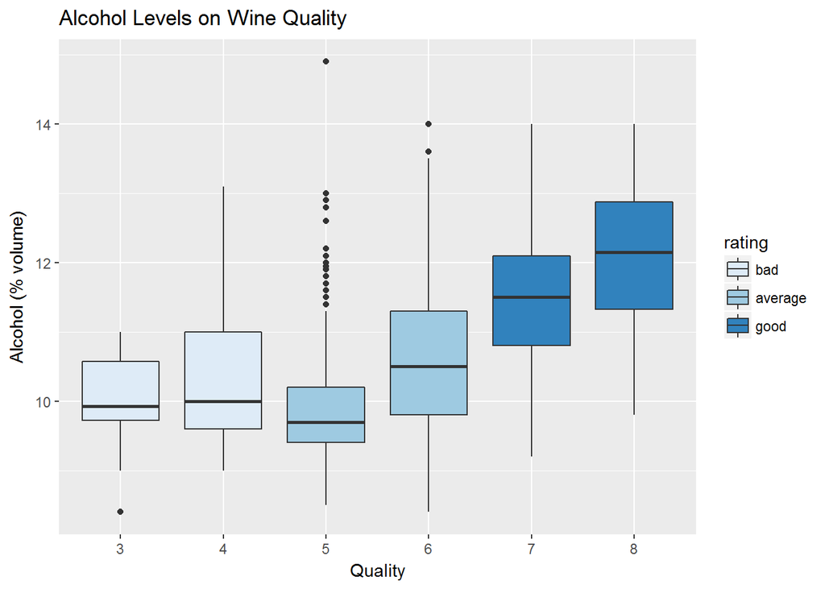

```r
ggplot(data = red_wine, aes(as.factor(quality), alcohol, fill = rating)) +
  geom_boxplot() +
  ggtitle('Alcohol Levels on Wine Quality') +
  xlab('Quality') +
  ylab('Alcohol (% volume)') +
  scale_fill_brewer(type = 'seq', palette = 1)
```

### Description One

As alcohol is highly correlated with the quality, it is better to see its pattern with varying rating. From the above plot, it clearly shows higher % of alcohol yields better wine.

### Plot Two : Effect of acids on wine quality

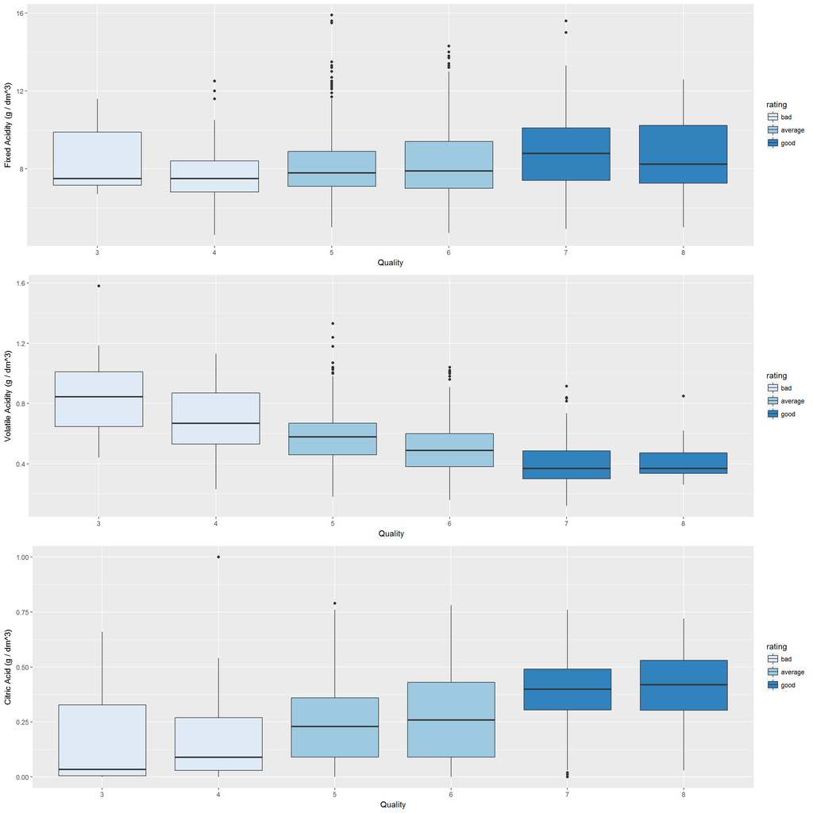

[figure not shown]

```r
ggplot(data = subset(red_wine, rating != 'good'), aes(alcohol, sulphates, color = rating)) +
  geom_point() +
  ggtitle('Alcohol vs Sulphates on Wine Quality') +
  xlab('Sulphates (g / dm^3)') +
  ylab('Alcohol (% volume)')
```

# Reflection

So, there are lots of features on which the wine quality is depend. We do a lot to find the relationship between every variables in the dataset, try to get some linear relation using geom_smooth(). And, after this EDA, I can conclude that the major factors for better wine quality is alcohol, acidity and sulphates. These features must also be in required content otherwise negative impact will effect the wine quality. Also, we can’t be totally sure about quality index also it has been taken by some experts. We’ve also concluded that there is linear relationship between pH and quality with negative slope.

One thing that is still unclear is the amount of residual.sugar. It contains many outliers, also after doing some operation we get its common range from 1 to 4. But we can’t find its amount for ideal wine quality. I think more future research need to be done to find its ideal quantity.

Also i have use Decision Tree as my model to train and test my dataset .